# Temperature

Project 5

Climate change has been at the heart of all concerns, especially among the new generations. Rightfully, since it has already had disastrous consequences for the animal and plant world, it threatens in the short-term many species, i.e., the polar bear, which feeds more and more difficult due to the degradation of the arctic ice pack. In addition to that, it is the source of many meteorological disasters; the 0NU estimates that the number of disasters has been multiplied by 5 in only 50 years. It is sad that human activity is the primary cause of climate change. Factors such as the aviation industry or plastic overproduction have contributed significantly to the emission of greenhouse gases. Greenhouse gases trap heat in the atmosphere, leading to rising temperatures. The consequences of global warming raise questions.

In this report, we will carefully analyze the temperature data set provided to gain a better understanding of its behavior and make predictions for the future. To do this, we will first explore the available data before building a model, beginning by the trend. We will take the time to interpret and verify it using various diagnostic techniques. Finally, we will discuss the results and provide a critical perspective.

# 1 Trend of the Model

This report will focus on the temperature data set spanning from 1880 to 2022, which is visually represented in Figure 1 below. It is then evident that the temperature tends to increase gradually over time. Moreover, a closer inspection of the data reveals that it can be divided into two distinct periods: the first period, lasting until 1960, in which temperatures remain relatively constant with minor fluctuations, and the second period, beginning in 1960. Within the context of this analysis, we will only focus on the second one.

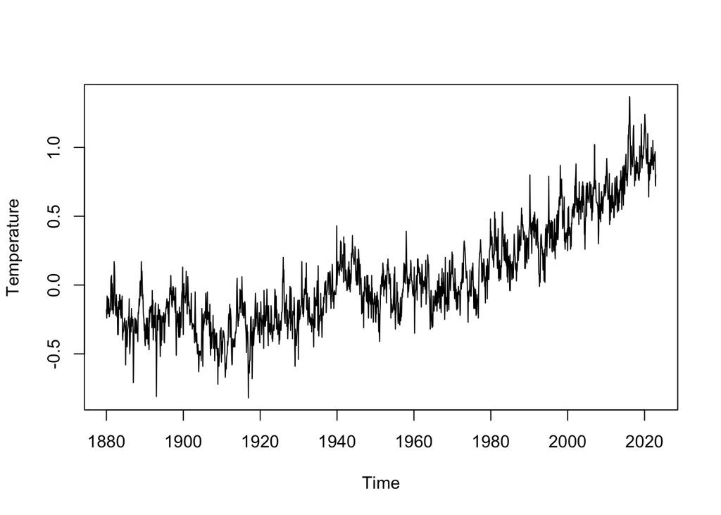

Figure 1: Illustration of the time series ‘temperature.’

*Note : The data points are joined by lines for readability despite the fact that the data is discrete with one value per month.*

*Note 2 : the data does not seem to show any difference in variance and thus does not require any transformation.*

The temperatures in this data set have been recorded monthly for several years. However, it is known that temperatures vary from month to month, with hotter temperatures in summer and colder temperatures in winter. Therefore, it would make complete sense to build a time series model with seasonality (with a lag of 12) in order to capture these patterns.

Furthermore, as previously mentioned, it is evident that the data exhibits an increasing trend. Hence, decomposing the time series into its underlying components will provide valuable insights into the individual factors contributing to its overall behavior. This is why we represent our data as $X_t = Y_t + T_t + S_t$, where:

- $X_t$ is the temperature
- $S_t = S_{t+12}$ is the seasonal component
- $T_t$ is the trend component
- $Y_t$ is the stationary remainder with zero mean.

In this initial section, our objective will be to find an appropriate trend for the model. And therefore to understand the overall behavior of the temperature. Without this step, the time series has no chance to be stationary, as the mean is not constant. The stationarity is indeed an essential property which allows us to do statistics on a single observation.

## 1.1 Hypothesis

To fit the trend, we will explore three possible forms: linear, quadratic, and exponential. The idea is to initially fit a model using all the forms and after to determine if some can be omitted.

Then we first begin to fit using the formula below, and we show the result of the regression in Figure 2.

`temp` ~ `t` + `t^2` + `exp(t/1000)` + `month`

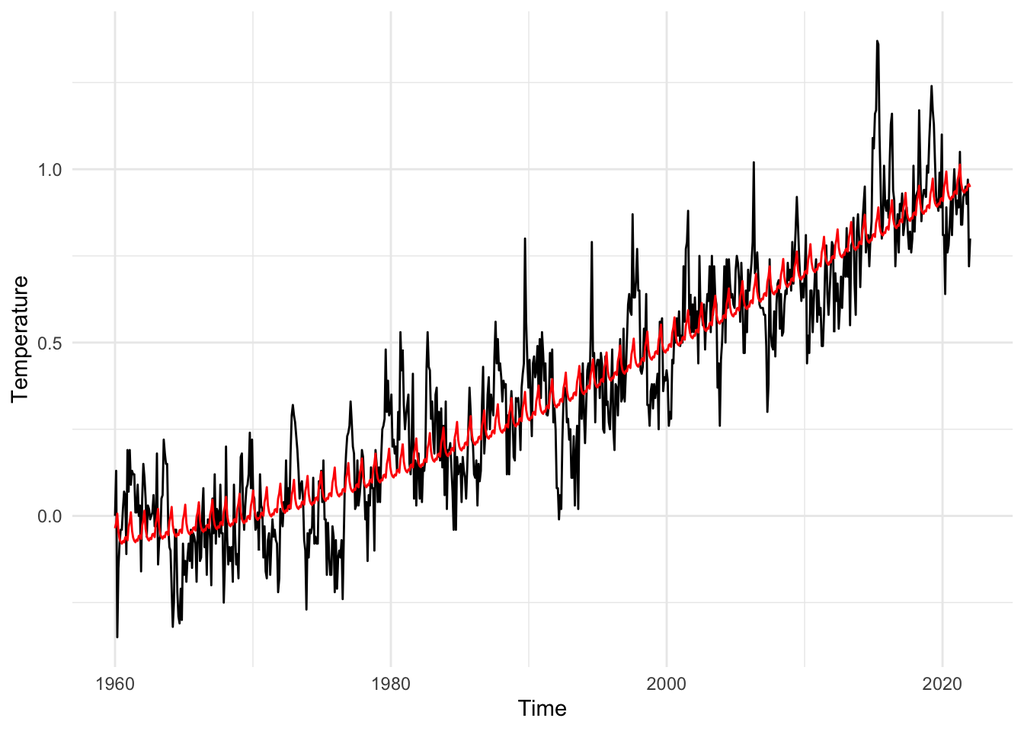

Figure 2: Illustration of the data from 1960 to 2022 and in red the fitted trend (obtained with the function `lm`).

In Figure 2, we can see that the fitted trend doesn’t seem too bad. Indeed, it follows the general behavior of the data.

## 1.2 Generalized Least Squares (GLS)

It is important to recognize that when fitting a linear regression model, one of the fundamental assumptions is that the observations should be independent. However, in cases such as time series data, this assumption is often violated. The series $(X_t)$ is serially correlated. As a result, the model may produce biased results and the residuals may be correlated, leading to unreliable estimates of standard error, confidence intervals, and p-values.

To overcome this issue, one possible solution is to use Generalized Least Squares (GLS) instead. GLS accounts for unequal error variances and correlations between different errors.

In both methods we aim to solve : $y = X\beta + \epsilon$.

Where ordinary least squares (OLS) assumes that the errors are independent and identically distributed, $\epsilon$ ~ $N(0, \sigma^2 I)$, generalized least squares (GLS) assumes that they are correlated and may have unequal variances, $\epsilon$ ~ $N(0, \sigma^2 \Sigma)$.

Then the minimum of $\lVert X\beta - y \rVert$ appears to be $\beta_{\text{GLS}} = (X^T \Sigma X)^{-1} X^T \Sigma^{-1}y$. It is calculated by the “Maximum Likelihood” method. However, in this case the matrix $\Sigma$ is not known and therefore has to be estimated from the data with the help of the function `corARMA`. This function computes the correlation matrix of the residuals, specifying the ARMA model parameters followed by these residuals. Therefore the next step would be to find an appropriate ARMA model to fit the residuals.

## 1.3 ARMA and Residuals

We first start by plotting the “residuals” process obtained after the regression. It then appears to be stationary as shown in the Figure 3. There is no more apparent trend or seasonality and the series seems to have zero mean which is very encouraging. However, it is very difficult to prove the stationary of a series and therefore, we can only make the hypothesis.

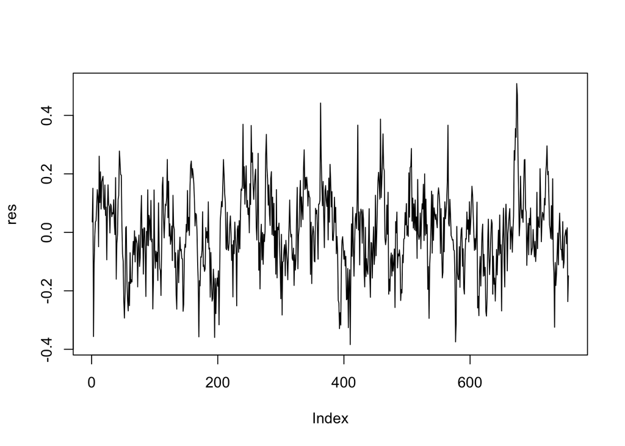

Figure 3: Residuals of the previous regression.

To recall, the process $(X_t, t \in \mathbb{Z})$ is said to be an ARMA (p, d) if
$$\phi_{[p]}(B)X_t = \theta_{[q]}(B) Z_t$$
where $Z_t$ is white noise and $\phi_{[p]}(B)$ and $\theta_{[q]}(B)$ are polynomials of the designated order.

One common way to determine the parameters of an ARMA model is to analyze the autocorrelation function (ACF) and partial autocorrelation function (PACF) of the process. These functions provide insights into the correlation structures between the terms, helping to identify the appropriate orders p and q for respectively the auto regressive (AR) and the moving average (MA) components.

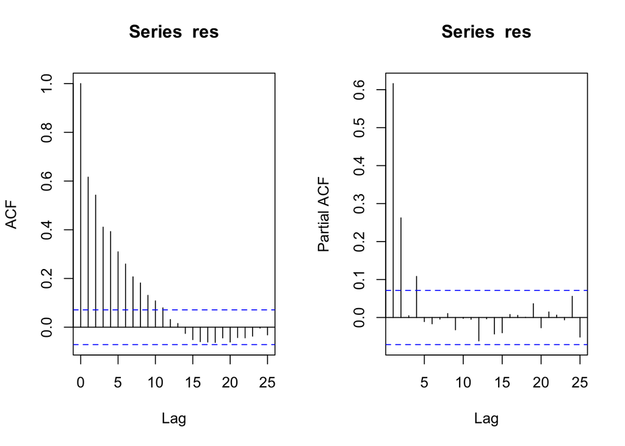

Figure 4: ACF and PACF of the process.

We observe that the PACF exhibits two significant spikes at lag 1 and 2. This indicates a dependence between $R_t$ (the residual at time t) and $R_{t-2}$ which is not provided by the intervention of $R_{t-1}$. Moreover, the ACF shows an exponential decay. Both are characteristic traits of an auto regressive process. Therefore, this suggests fitting an AR(2) model.

*Note : The analysis of the residuals for this fitting model was performed in the code but is not reported in the report.*

## 1.4 Applications

Now that we have the dependence structure of our residuals, in this section we will look at each of the components to determine whether they help to explain the behavior of temperatures. We will first focus on the exponential term before analyzing the quadratic term and finally questioning the importance of the term responsible for the seasonality: `month`.

### 1.4.1 Exponential Term

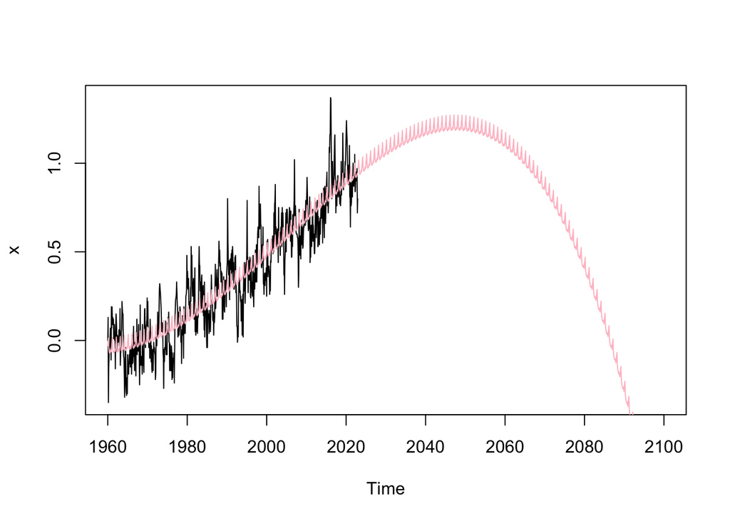

Figure 5: Trend fitted with linear, quadratic and exponential term.

Table 1: ANOVA table to compare the full model and the one without the exponential component.

|  | Model | Df | logLik | L.Ration | p-value |
| --- | --- | --- | --- | --- | --- |
| subfit_1 | 1 | 17 | 637.22 |  |  |
| glsfit | 2 | 18 | 637.78 | 1 | 0.29 |

Therefore, we conclude that the model fitted is not explained by the exponential term and it may be reasonable to exclude this term from the model.

### 1.4.2 Quadratic Term

Table 2: ANOVA table to compare the model without the exponential component and the one without the quadratic term.

|  | Model | Df | logLik | L.Ration | p-value |
| --- | --- | --- | --- | --- | --- |
| subfit_2 | 1 | 16 | 633.19 |  |  |
| subfit_1 | 2 | 17 | 637.22 | 8 | 0.0045 |

Therefore we can not deny a possibly quadratic term in the trend.

*Note : A similar reasoning can be made for the linear term `t` where we found a p-value of 0.0053.*

### 1.4.3 Seasonality

The following question we will address is whether seasonality needs to be incorporated into the trend. To investigate this, we will examine the “month” variable in the regression. The following ANOVA table, which compares the model with and without it, shows that it actually has an impact on the model, and remove it will change the results.

Table 3: ANOVA table to compare the model without the exponential component and the one without the seasonal term.

|  | Model | Df | logLik | L.Ration | p-value |
| --- | --- | --- | --- | --- | --- |
| subfit_2 | 1 | 6 | 620.61 |  |  |
| subfit_1 | 2 | 17 | 637.22 | 33 | 0.00048 |

Moreover the AIC of the first model is -1240.45 against -1229.21, therefore even they are close, the first one stay the lowest. In conclusion, we can not confidently reject this hypothesis, even though we understand that it may not be very significant in the model.

# 2 SARIMA Model

The Seasonal Auto Regressive Integrated Moving Average (SARIMA) model is a popular method to fit time series which present some seasonal and non seasonal trends. It is an extension of the ARIMA and ARMA models.

Indeed, by definition the process $(X_t, t \in \mathbb{Z})$ is said to be a SARIMA (p, d, q) x (P, D, Q$)_s$ if
$$\Phi_{[P]} (B^s) \phi_{[p]}(B) (1 - B^s)^D
(1-B)^d X_t = \Theta_{[Q]}(B^s) \theta_{[q]}(B) Z_t$$
where $Z_t$ is white noise and $\Phi_{[P]} (B^s), \phi_{[p]}(B), \Theta_{[Q]}(B^s)$ and $\theta_{[q]}(B)$ are polynomials of the designated order.

Therefore the SARIMA model is a very useful tool to fit and predict time series, it will be able to capture trend and seasonal variations if they exist. That is why it is a very interesting for our data set since temperatures are known to vary seasonally.

## 2.1 Differencing

In the previous section, we determined that the trend consists of linear, quadratic, and monthly components. We can then observe that (with $B$ the back shift operator) :

$$(1-B)^2(1-B^{12}) X_t =
(1-B)^2(1-B^{12}) (Y_t + T_t + S_t) = (1-B)^2 (Y_t - Y_{t-12} + T_t -
T_{t -12})$$
$$= (1-B)^2 (Y_t -
Y_{t-12} + (at^2 +bt +c) - (a(t-12)^2 + b(t-12) +c)) = (1-B)^2 (Y_t -
Y_{t-12} + 24ta -144a + b12))$$

$$= (1-B) ((Y_t - Y_{t-12} + 24ta -144a +
b12) - (Y_{t-1} - Y_{t-13} + 24ta -24a -144a + b12)) = (1-B) (Y_t -
Y_{t-12} - Y_{t-1} + Y_{t-13} + 24a )$$

$$= (1-B)^2(1-B^{12})Y_t$$

It can indeed be observed that after differentiating with lag 12 and twice with lag 1, we obtain something that appears to be more stationary as shown in the Figure 6. There is no more apparent trend or seasonality and the series seems to have zero mean. We will thus construct a model on this differentiated series.

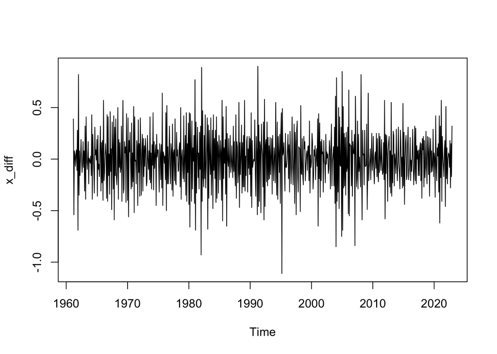

Figure 6: The process obtained after differencing at lag 1 twice and lag 12 once.

## 2.2 Construction of the model

As enumerate before, we aim to fit a SARIMA model, we just determine that d=2 and D=1. In order to estimate the others parameters we study the ACF and PACF of this resulting process. Indeed, the ACF and PACF are not only good to find the parameters p and q of the Auto Regressive and Moving Average process, but also P and Q of an ARMA or ARIMA model. Indeed, if both graphs show spikes at certain lags, then those spikes should be considered in the construction of the model.

However, it is important to note at this point of the analysis that the estimated values of the ACF and PACF obtained using the method of moments are biased. This means that as we observe larger lags, we have fewer values available for estimation, resulting in decreased precision. Therefore, we have chosen to focus our analysis on lags smaller than $10 \log_{10}(n)$, which is 28 in our specific case.

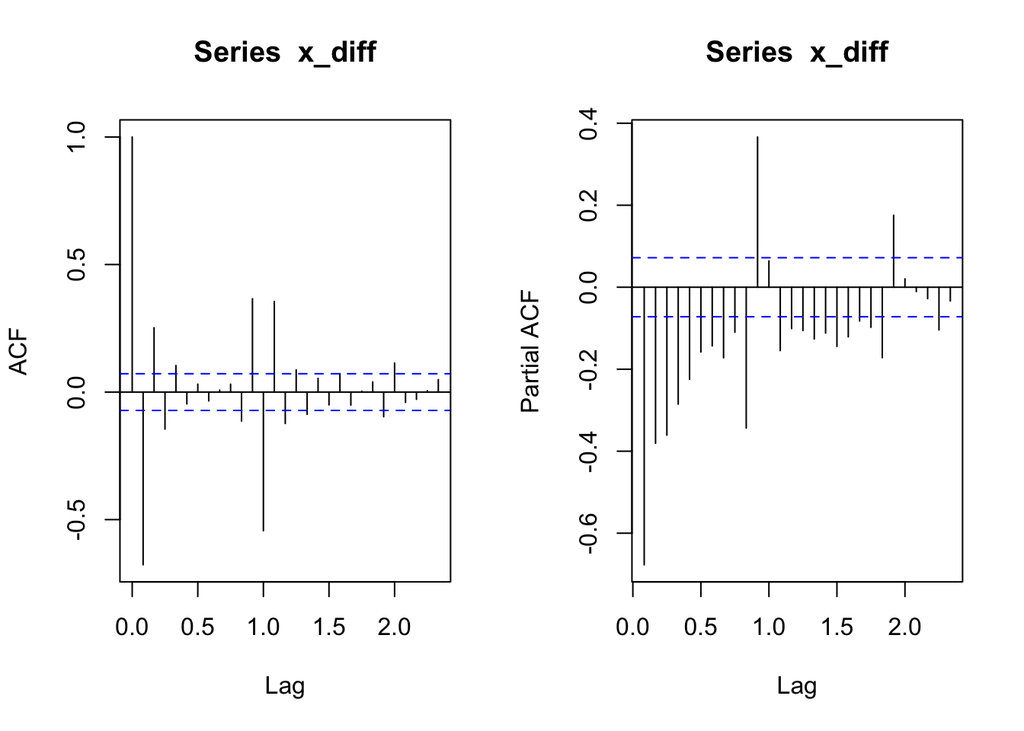

Figure 7: ACF and PACF of the process.

We now need to determine the p, q, P, and Q parameters for our model. As mentioned before, the ACF plot will allow us to determine q and Q for our model. Indeed, a significant pic at lag k means that there is an important correlation and therefore a dependence. Specifically, we can observe that there are 1 or 4 significant spikes in the beginning of the plot (depending if we include those that slightly exceed the blue line), with the spike at lag 12 being particularly important. This leads us to conclude that q=1 or 4, and Q=1.

Similarly, we can use the PACF plot to determine the p and P parameters. A spike at lag k in the PACF plot indicates a correlation between $X_t$ and $X_{t+k}$, after removing the influence of all intermediate observations $X_{t+1}$, $X_{t+2}$, …, $X_{t+k-1}$. After examining the PACF plot, we observe there are a lot of significant spikes outside the blue line, however we can only choose to concentrate on the most significant ones. Therefore we obtain that there is 1 or 3 significant spikes at the beginning and two more at lags 12 and 24. This leads us to conclude that p=1 or 3 and P=2.

In conclusion we obtain two possible models, depending on the confidence level we impose :

`(p, d, q, P, D, Q, s) = (1, 2, 1, 2, 1, 1, 12)` or `(p, d, q, P, D, Q, s) = (3, 2, 4, 2, 1, 1, 12)`

We can then fit the two models with the `arima` function. The function will estimate the parameters by Gaussian MLE.

When fitting a SARIMA model to a time series, one common way to compare different models is to look at their AIC values. A lower AIC indicates a better model fit, so we might expect the model with the smaller AIC to be the better choice. In this case, the AIC values are respectively : -1093.61 and -1117.77. And it therefore appears that the second one is the most appropriate for the data.

The function `arima` determine the parameters of the polynomials: $\Phi_{[P]} (B^s), \phi_{[p]}(B), \Theta_{[Q]}(B^s)$ and $\theta_{[q]}(B)$ as there is a one to one correspondence between the auto covariance and the model parameters. We then obtain the following summary for our model :

```
##
## Call:
## arima(x = x, order = c(3, 2, 4), seasonal = list(order = c(2, 1, 1), period = 12))
##
## Coefficients:
##           ar1      ar2      ar3      ma1     ma2      ma3     ma4     sar1
##       -0.3571  -0.5555  -0.0405  -1.1389  0.5242  -0.7320  0.3470  -0.0329
## s.e.      NaN      NaN   0.0130   0.0041  0.0195   0.0131  0.0156   0.0048
##         sar2     sma1
##       0.1056  -0.9744
## s.e.  0.0040   0.0142
##
## sigma^2 estimated as 0.01173:  log likelihood = 569.88,  aic = -1117.77
##
## Training set error measures:
##                         ME      RMSE        MAE MPE MAPE     MASE        ACF1
## Training set -0.0002823565 0.1072958 0.08499861 NaN  Inf 0.884426 0.005038336
```

## 2.3 Residual Diagnostics

As in all construction of models in mathematics it is essential to perform diagnostics of our result model. Many diagnostics are possible to access the validity of the model, we present here three of them.

The first one is related to the fact that the residuals of the fitting model should be roughly Gaussian. To verify this condition we make a QQ-plot of the residuals, which is shown in the Figure 8 below. And as we can see they form indeed a straight line which is a very encouraging result.

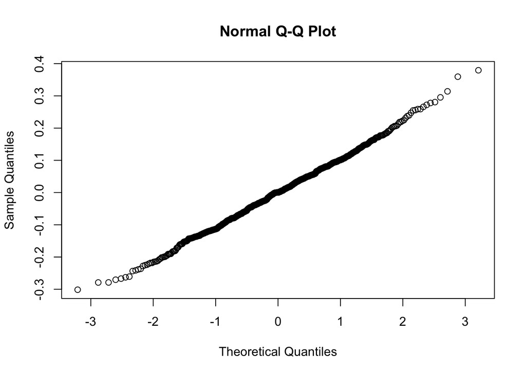

Figure 8: QQ-plot of the model’s residuals.

Moreover, another property is that the residuals should be white noise. To verify this, we can plot the ACF and PACF, as shown in Figure 9. Here again, the results are quite satisfying as there are no spike outside the blue lines, except one little.

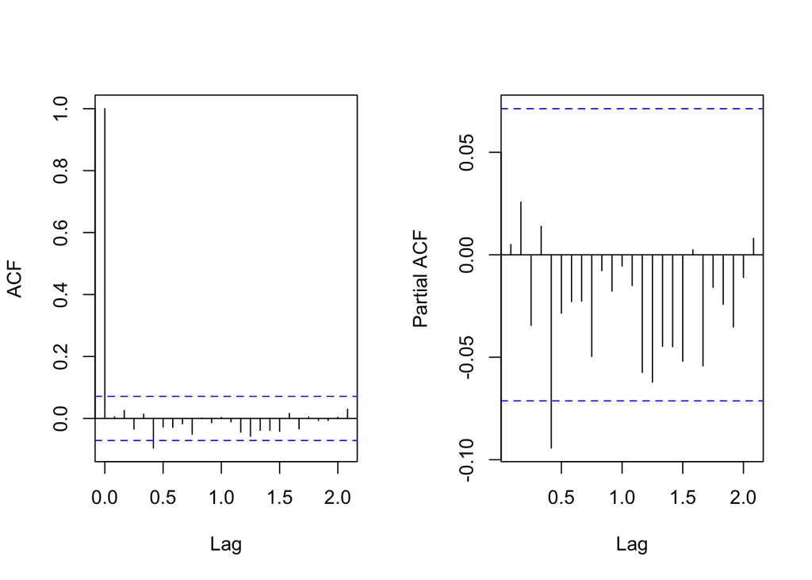

Figure 9: ACF and PACF of the residuals.

Another method to assess the quality of a fitted model is to simulate data from it. In this case, it means generating data from the year 1960 to 2022 and comparing it to the original data set that was used for fitting the model. The results of the simulation are shown in Figure 10, and are quite encouraging. The pink curve follows the major fluctuations of the process and has the same overall behavior. However, one observation that can be made is that the model tends to underestimate extreme values from the trend, such as high perturbations or black spikes.

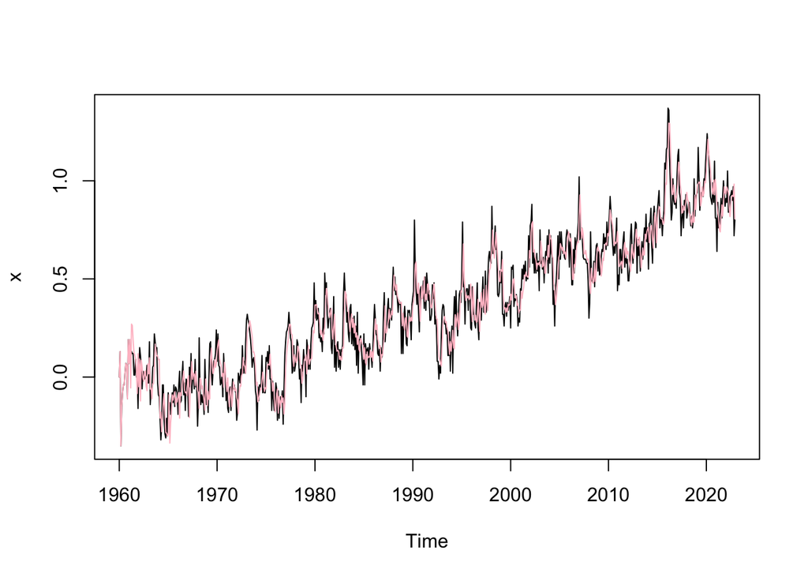

Figure 10: Comparison between the data set and the simulation from the fitted model.

## 2.4 Predictions

The primary objective of studying time series is often to make predictions with a certain degree of accuracy, along with a corresponding confidence interval. In this section, we will use the `forecast` function to achieve this goal. The figure below displays the predicted values up to 2050.

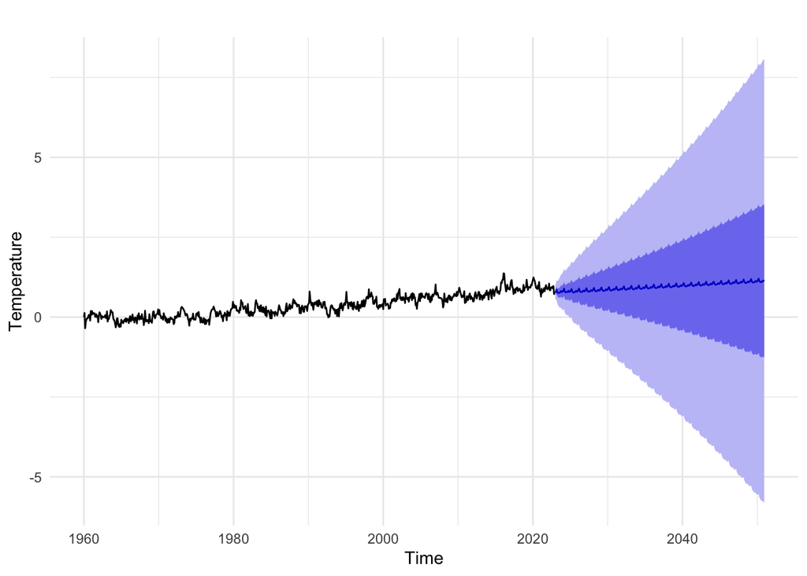

Figure 11: Prediction of the temperature until 2050 with the model established.

We can observe something very surprising here: the confidence interval is extremely large, producing completely unusable results. There could be several reasons for this. Firstly, it is a model that has a lot of parameters, and as each parameter is estimated, each new parameter introduces uncertainty into the model. Additionally, the quadratic models are known to be more complex than linear models, and it makes it more sensitive to extreme values. It is also worth noting that the small size of the data set being studied can also increase uncertainty.

## 2.5 Another Model with Linear Trend

In order to compare with the model obtained in the previous section, we also fit a model with a linear trend. And we ended up with the model : `(p, d, q, P, D, Q, s) = (3, 1, 3, 2, 1, 1, 12)`

*Note : the exact same demonstration leading to this result can be shown in the document “Linear Model.Rmd”.*

We present the diagnostic plot to examine whether the residuals exhibit white noise characteristics. From the plot, we observe that there are no spikes outside the blue lines, indicating independence between the terms. However, we do notice a single spike in the ACF plot at lag 0, which is expected as it represents the autocorrelation and, by definition, $\frac{\gamma(0)}{\gamma(0)} = 1$.

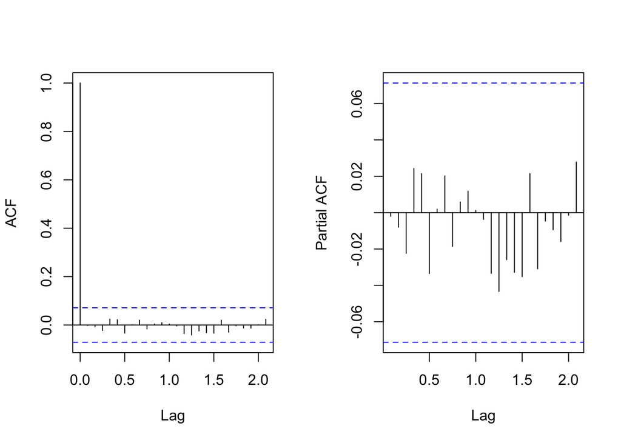

Figure 12: ACF and PACF of the residuals.

Moreover, we remark that it has an AIC lower than our model find in the quadratic case. It then emphasizes the idea that it is a better model.

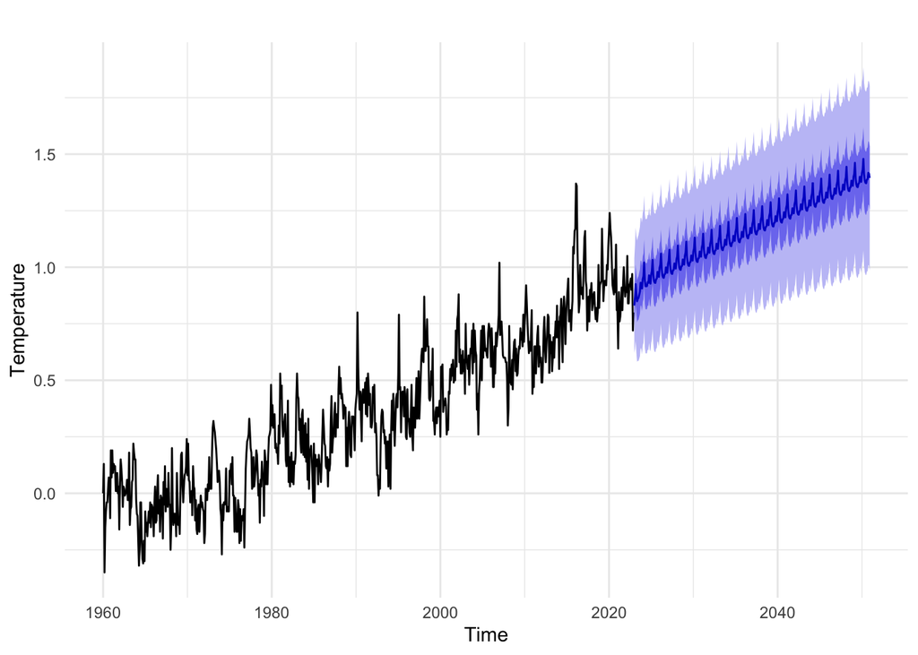

Figure 13: Prediction of the temperature until 2050 with the model established.

As we could expect, the prediction follow the linear trend that we assumed before. With this model, the prediction is not very optimistic for the future, as it predicts an increase and indicates that we will exceed 1 with a probability of 90% in 2050. Furthermore, although it may not be evident in the Figure, the confidence interval becomes increasingly wider and more significant as we attempt to predict further into the future.

## 2.6 Auto SARIMA fonction

In the R programming language, the forecast package includes a highly useful function called `auto.arima`, which is capable of automatically identifying the best SARIMA model for a given time series. `auto.arima` searches for the best model based on the Akaike information criterion (AIC) and considers only small orders to avoid over fitting.

When we applied this function to our data, the resulting best SARIMA model was:

```
## Series: x
## ARIMA(1,1,2)(2,0,1)[12]
##
## Coefficients:
##          ar1      ma1     ma2    sar1    sar2     sma1
##       0.8582  -1.3750  0.3897  0.6598  0.1169  -0.6526
## s.e.  0.0330   0.0517  0.0483  0.2189  0.0530   0.2212
##
## sigma^2 = 0.01147:  log likelihood = 617.37
## AIC=-1220.73   AICc=-1220.58   BIC=-1188.35
```

We then remark that the AIC of this model is not so far away from our previous result, and we are therefore confident in our previous analysis.

# 3 Conclusion

In conclusion, we began by analyzing different trend possibilities, and it appeared that we could not consider the exponential trend as acceptable. However, we could not reject the quadratic and seasonal components. Nevertheless, when fitting the SARIMA model with this type of trend, it became apparent that a lot of uncertainty rendered the results completely unusable. Moreover, a model with a linear trend had a better AIC, similar to the one obtained using the `auto.arima` function. Thus, the temperature trend would be linear and undoubtedly increasing, which raises many questions about the future. The rise in temperatures is not good news, and we must do everything we can to slow it down and change the forecast model. No matter the cause, it is necessary to take action right away in order to solve this problem and make the harmful effects on the Earth and its living creatures less severe.